# OSCBOP notes

Don Boyd

August 08, 2014

# Direct payments analysis

## Summary so far

### Conclusions

- USASpending may be a good source for US totals for direct payments spending - i.e., for knowing
  - Which programs are properly considered direct payments
  - US totals for these programs
- It is obvious that the USASpending state allocations don’t reflect what we think makes sense
  - For example, Pennsylvania has the greatest allocation (more than CA, FL, TX, NY, etc.). I suspect it is not an error in the data, per se, but it undoubtedly means the data do not mean what we want them to mean (e.g, perhaps a lot of checks for Social Security are processed in PA and perhaps that is how SSA decides where to “source” those payments).
  - And Maryland has negative direct payment totals, driven by negatives for the 3 Medicare programs
- Programs that look particularly suspect include:
  - 93.773 Medicare_Hospital Insurance
  - 93.774 Medicare_Supplementary Medical Insurance
  - 93.770 Medicare_Prescription Drug Coverage
  - 84.063 Federal Pell Grant Program certainly does not follow population distribution, but perhaps it is possible. Requires some investigation.
  - 57.001 Social Insurance for Railroad Workers ditto
- Two strategies to pursue:
  - 1. See if we can
    - “trust” the non-Medicare USASpending data
      - Is anything significant missing from USASpending?
      - Can we get info on how major programs are allocated
    - get good external data sources to allocate Medicare (links below)
  - 2. Alternatively, throw out ALL USASpending direct payments data (not just Medicaire) and pursue a BEA-based approach (discuss with Sam Amy-Rosen at Pew, Becky Sweger at NPP)

### Questions and TODO

- What is difference between principal_place_state_code and recipient_state_code? (Doesn’t look like it makes a lot of difference.)
- Can we find out what rules federal agencies are using for determining recipient_state_code for specific CFDA programs?
- Since Medicare is, by far, the largest of the most-suspect programs, can we find an alternative way to allocate it?
- Can we investigate Pell Grants and also 57.001?

## USASpending totals: detailed data compared to online data

Totals from detailed data and from online USASpending (screenshot 8/8/2014)

[figure not shown]

## Quick look at top direct payments by various groupings

Top direct payments by agency

| agency_name | fed_funding_amount | cumsum | pct | cumpct |
| --- | --- | --- | --- | --- |
| SOCIAL SECURITY ADMINISTRATION | 858.49 | 858.5 | 55.93 | 55.93 |
| CENTERS FOR MEDICARE AND MEDICAID SERVICES | 516.42 | 1374.9 | 33.65 | 89.58 |
| UNDER SECRETARY FOR BENEFITS/VETERANS BENEFITS ADMINISTATION | 76.16 | 1451.1 | 4.96 | 94.54 |
| EDUCATION, DEPARTMENT OF | 32.70 | 1483.8 | 2.13 | 96.67 |
| RAILROAD RETIREMENT BOARD | 11.73 | 1495.5 | 0.76 | 97.44 |
| ASST SECRETARY FOR HOUSING–FEDERAL HOUSING COMMISSIONER | 11.42 | 1506.9 | 0.74 | 98.18 |
| FARM SERVICE AGENCY | 10.12 | 1517.0 | 0.66 | 98.84 |
| FOOD AND NUTRITION SERVICE | 8.06 | 1525.1 | 0.52 | 99.37 |
| UNDER SECRETARY FOR HEALTH/VETERANS HEALTH ADMINISTRATION | 4.63 | 1529.7 | 0.30 | 99.67 |
| INDIAN HEALTH SERVICE | 2.07 | 1531.8 | 0.13 | 99.80 |

Top direct payments by cfda

| cfda_program_num | cfda_program_title | fed_funding_amount | cumsum | pct | cumpct |
| --- | --- | --- | --- | --- | --- |
| 96.002 | Social Security_Retirement Insurance | 584.65 | 584.6 | 38.09 | 38.09 |
| 93.773 | Medicare_Hospital Insurance | 238.60 | 823.2 | 15.55 | 53.64 |
| 93.774 | Medicare_Supplementary Medical Insurance | 219.65 | 1042.9 | 14.31 | 67.95 |
| 96.001 | Social Security_Disability Insurance | 139.31 | 1182.2 | 9.08 | 77.03 |
| 96.004 | Social Security_Survivors Insurance | 81.75 | 1264.0 | 5.33 | 82.35 |
| 93.770 | Medicare_Prescription Drug Coverage | 56.31 | 1320.3 | 3.67 | 86.02 |
| 64.109 | Veterans Compensation for Service-Connected Disability | 52.94 | 1373.2 | 3.45 | 89.47 |
| 96.006 | Supplemental Security Income | 52.78 | 1426.0 | 3.44 | 92.91 |
| 84.063 | Federal Pell Grant Program | 31.00 | 1457.0 | 2.02 | 94.93 |
| 57.001 | Social Insurance for Railroad Workers | 11.65 | 1468.7 | 0.76 | 95.69 |
| 14.195 | Section 8 Housing Assistance Payments Program | 10.91 | 1479.5 | 0.71 | 96.40 |
| 64.028 | Post-9/11 Veterans Educational Assistance | 9.80 | 1489.3 | 0.64 | 97.04 |
| 10.551 | Supplemental Nutrition Assistance Program | 6.07 | 1495.4 | 0.40 | 97.43 |
| 64.110 | Veterans Dependency and Indemnity Compensation for Service-Connected Death | 5.35 | 1500.8 | 0.35 | 97.78 |
| 10.055 | Direct and Counter-cyclical Payments Program | 4.91 | 1505.7 | 0.32 | 98.10 |

Top direct payments by recip_cat_type

| recip_cat_type | fed_funding_amount | cumsum | pct | cumpct |
| --- | --- | --- | --- | --- |
| i: Individual | 959.60 | 959.6 | 62.52 | 62.52 |
| f: For-Profit Organization | 300.76 | 1260.4 | 19.60 | 82.12 |
| o: Other | 120.09 | 1380.4 | 7.82 | 89.94 |
| g: Government | 67.46 | 1447.9 | 4.40 | 94.34 |
| n: Non-Profit Organization | 66.93 | 1514.8 | 4.36 | 98.70 |
| h: Higher Education | 20.00 | 1534.8 | 1.30 | 100.00 |

Top direct payments by recipient type

| recipient_type | fed_funding_amount | cumsum | pct | cumpct |
| --- | --- | --- | --- | --- |
| 21: Individual | 959.60 | 959.6 | 62.52 | 62.52 |
| 22: Profit organization | 232.06 | 1191.7 | 15.12 | 77.64 |
| 25: All other | 120.09 | 1311.8 | 7.82 | 85.46 |
| 23: Small business | 68.70 | 1380.4 | 4.48 | 89.94 |
| 12: Other nonprofit | 64.22 | 1444.7 | 4.18 | 94.12 |
| 01: County government | 31.94 | 1476.6 | 2.08 | 96.21 |
| 00: State government | 30.14 | 1506.8 | 1.96 | 98.17 |
| 06: State controlled institution of higher education | 13.19 | 1519.9 | 0.86 | 99.03 |
| 20: Private higher education | 6.81 | 1526.8 | 0.44 | 99.47 |
| 05: Independent school district | 4.00 | 1530.8 | 0.26 | 99.73 |

Top county government direct payments by cfda

| cfda_program_num | cfda_program_title | fed_funding_amount | cumsum | pct | cumpct |
| --- | --- | --- | --- | --- | --- |
| 93.774 | Medicare_Supplementary Medical Insurance | 15.73 | 15.73 | 49.25 | 49.25 |
| 93.773 | Medicare_Hospital Insurance | 14.93 | 30.67 | 46.75 | 96.00 |
| 84.063 | Federal Pell Grant Program | 1.13 | 31.80 | 3.54 | 99.54 |
| 93.770 | Medicare_Prescription Drug Coverage | 0.09 | 31.88 | 0.27 | 99.81 |
| 93.210 | Tribal Self-Governance Program: IHS Compacts/Funding Agreements | 0.03 | 31.91 | 0.09 | 99.90 |
| 84.033 | Federal Work-Study Program | 0.02 | 31.93 | 0.05 | 99.95 |
| 84.007 | Federal Supplemental Educational Opportunity Grants | 0.02 | 31.94 | 0.05 | 100.00 |
| 93.441 | Indian Self-Determination | 0.00 | 31.94 | 0.00 | 100.00 |
| 84.379 | Teacher Education Assistance for College and Higher Education Grants (TEACH Grants) | 0.00 | 31.94 | 0.00 | 100.00 |

Top state government direct payments by cfda

| cfda_program_num | cfda_program_title | fed_funding_amount | cumsum | pct | cumpct |
| --- | --- | --- | --- | --- | --- |
| 93.773 | Medicare_Hospital Insurance | 13.32 | 13.32 | 44.20 | 44.20 |
| 93.774 | Medicare_Supplementary Medical Insurance | 13.03 | 26.35 | 43.23 | 87.42 |
| 10.566 | Nutrition Assistance For Puerto Rico | 1.99 | 28.34 | 6.60 | 94.02 |
| 84.063 | Federal Pell Grant Program | 0.93 | 29.27 | 3.08 | 97.10 |
| 97.048 | Federal Disaster Assistance to Individuals and Households in Presidential Declared Disaster Areas | 0.43 | 29.70 | 1.44 | 98.54 |
| 10.551 | Supplemental Nutrition Assistance Program | 0.15 | 29.85 | 0.49 | 99.02 |
| 93.529 | Pre-existing Condition Insurance Program (PCIP) | 0.11 | 29.95 | 0.36 | 99.38 |
| 15.875 | Economic, Social, and Political Development of the Territories | 0.07 | 30.02 | 0.23 | 99.61 |
| 93.770 | Medicare_Prescription Drug Coverage | 0.05 | 30.07 | 0.16 | 99.77 |
| 93.441 | Indian Self-Determination | 0.02 | 30.09 | 0.07 | 99.84 |

Top state higher ed direct payments by cfda

| cfda_program_num | cfda_program_title | fed_funding_amount | cumsum | pct | cumpct |
| --- | --- | --- | --- | --- | --- |
| 84.063 | Federal Pell Grant Program | 12.49 | 12.49 | 94.67 | 94.67 |
| 84.033 | Federal Work-Study Program | 0.38 | 12.87 | 2.91 | 97.58 |
| 84.007 | Federal Supplemental Educational Opportunity Grants | 0.26 | 13.14 | 2.00 | 99.58 |
| 84.379 | Teacher Education Assistance for College and Higher Education Grants (TEACH Grants) | 0.05 | 13.19 | 0.36 | 99.94 |
| 10.069 | Conservation Reserve Program | 0.00 | 13.19 | 0.02 | 99.96 |
| 10.055 | Direct and Counter-cyclical Payments Program | 0.00 | 13.19 | 0.02 | 99.98 |
| 20.205 | Highway Planning and Construction | 0.00 | 13.19 | 0.01 | 99.99 |
| 10.603 | Emerging Markets Program | 0.00 | 13.19 | 0.00 | 99.99 |
| 15.030 | Indian Law Enforcement | 0.00 | 13.19 | 0.00 | 99.99 |
| 10.054 | Emergency Conservation Program | 0.00 | 13.19 | 0.00 | 100.00 |

Top direct payments by project description

| project_description | fed_funding_amount | cumsum | pct | cumpct |
| --- | --- | --- | --- | --- |
|  | 946.80 | 946.8 | 61.69 | 61.69 |
| Medicare: Hospital Insurance | 238.60 | 1185.4 | 15.55 | 77.23 |
| Medicare: Supplementary Medical Insurance | 219.65 | 1405.1 | 14.31 | 91.54 |
| Medicare Prescription Drug Coverage | 56.31 | 1461.4 | 3.67 | 95.21 |
| GRANT PROGRAM | 30.95 | 1492.3 | 2.02 | 97.23 |
| CONT RENEWALS ALL TYPES | 9.99 | 1502.3 | 0.65 | 97.88 |
| Supplemental Nutrition Assistance Program | 6.07 | 1508.4 | 0.40 | 98.28 |
| Direct and Counter-cyclical Payments Program: To provide income support to eligible producers of covered commodities. | 4.91 | 1513.3 | 0.32 | 98.60 |
| VHA CBO Purchased Care | 4.63 | 1517.9 | 0.30 | 98.90 |
| Nutrition Assistance For Puerto Rico | 1.99 | 1519.9 | 0.13 | 99.03 |

Top direct payments by principal_place_state_code

| principal_place_state_code | fed_funding_amount | cumsum | pct | cumpct |
| --- | --- | --- | --- | --- |
| PA | 133.16 | 133.2 | 8.68 | 8.68 |
| CA | 114.84 | 248.0 | 7.48 | 16.16 |
| FL | 102.89 | 350.9 | 6.70 | 22.86 |
| SC | 88.32 | 439.2 | 5.75 | 28.62 |
| IN | 80.07 | 519.3 | 5.22 | 33.83 |
| TX | 74.64 | 593.9 | 4.86 | 38.70 |
| WI | 72.15 | 666.1 | 4.70 | 43.40 |
| NY | 71.71 | 737.8 | 4.67 | 48.07 |
| TN | 53.24 | 791.0 | 3.47 | 51.54 |
| KY | 48.27 | 839.3 | 3.14 | 54.68 |

Top direct payments by recipient_state_code

| recipient_state_code | fed_funding_amount | cumsum | pct | cumpct |
| --- | --- | --- | --- | --- |
| PA | 133.24 | 133.2 | 8.68 | 8.68 |
| CA | 115.18 | 248.4 | 7.50 | 16.19 |
| FL | 102.94 | 351.4 | 6.71 | 22.89 |
| SC | 88.43 | 439.8 | 5.76 | 28.65 |
| IN | 80.19 | 520.0 | 5.22 | 33.88 |
| TX | 74.74 | 594.7 | 4.87 | 38.75 |
| WI | 72.29 | 667.0 | 4.71 | 43.46 |
| NY | 71.87 | 738.9 | 4.68 | 48.14 |
| TN | 53.26 | 792.1 | 3.47 | 51.61 |
| KY | 48.28 | 840.4 | 3.15 | 54.76 |

Top NY recip direct payments by cfda

| cfda_program_num | cfda_program_title | fed_funding_amount | cumsum | pct | cumpct |
| --- | --- | --- | --- | --- | --- |
| 96.002 | Social Security_Retirement Insurance | 37.19 | 37.19 | 51.74 | 51.74 |
| 96.001 | Social Security_Disability Insurance | 8.41 | 45.60 | 11.71 | 63.45 |
| 96.004 | Social Security_Survivors Insurance | 4.64 | 50.24 | 6.46 | 69.91 |
| 96.006 | Supplemental Security Income | 4.28 | 54.52 | 5.96 | 75.86 |
| 93.773 | Medicare_Hospital Insurance | 4.12 | 58.64 | 5.74 | 81.60 |
| 93.774 | Medicare_Supplementary Medical Insurance | 3.96 | 62.60 | 5.51 | 87.11 |
| 93.770 | Medicare_Prescription Drug Coverage | 1.99 | 64.60 | 2.77 | 89.88 |
| 64.109 | Veterans Compensation for Service-Connected Disability | 1.68 | 66.27 | 2.33 | 92.21 |
| 84.063 | Federal Pell Grant Program | 1.64 | 67.92 | 2.29 | 94.50 |
| 14.195 | Section 8 Housing Assistance Payments Program | 1.47 | 69.38 | 2.04 | 96.54 |
| 57.001 | Social Insurance for Railroad Workers | 0.47 | 69.85 | 0.65 | 97.19 |
| 10.551 | Supplemental Nutrition Assistance Program | 0.44 | 70.29 | 0.61 | 97.80 |
| 64.028 | Post-9/11 Veterans Educational Assistance | 0.42 | 70.71 | 0.59 | 98.38 |
| 64.110 | Veterans Dependency and Indemnity Compensation for Service-Connected Death | 0.17 | 70.88 | 0.24 | 98.62 |
| 97.048 | Federal Disaster Assistance to Individuals and Households in Presidential Declared Disaster Areas | 0.14 | 71.02 | 0.20 | 98.82 |

## USASpending recipient-state allocations for individual large direct payment programs

```
##
## Top 96.002 Social Security_Retirement Insurance direct payments by recipient_state_code
```

```
##
##
## |recipient_state_code | fed_funding_amount| cumsum|  pct| cumpct|
## |:--------------------|------------------:|------:|----:|------:|
## |CA                   |              56.31|  56.31| 9.63|   9.63|
## |FL                   |              44.07| 100.38| 7.54|  17.17|
## |NY                   |              37.19| 137.57| 6.36|  23.53|
## |TX                   |              35.36| 172.92| 6.05|  29.58|
## |PA                   |              28.36| 201.29| 4.85|  34.43|
## |IL                   |              22.78| 224.07| 3.90|  38.33|
## |MI                   |              22.16| 246.23| 3.79|  42.12|
## |OH                   |              22.02| 268.25| 3.77|  45.88|
## |NC                   |              19.07| 287.32| 3.26|  49.14|
## |NJ                   |              18.43| 305.76| 3.15|  52.30|
## |GA                   |              15.67| 321.43| 2.68|  54.98|
## |VA                   |              14.22| 335.65| 2.43|  57.41|
## |IN                   |              13.19| 348.84| 2.26|  59.67|
## |WA                   |              13.04| 361.87| 2.23|  61.90|
## |AZ                   |              12.78| 374.66| 2.19|  64.08|
```

```
##
## Top 93.773 Medicare_Hospital Insurance direct payments by recipient_state_code
```

```
## This is obviously not allocated by where the beneficiaries are!
```

```
##
##
## |recipient_state_code | fed_funding_amount| cumsum|   pct| cumpct|
## |:--------------------|------------------:|------:|-----:|------:|
## |PA                   |              44.32|  44.32| 18.58|  18.58|
## |SC                   |              36.52|  80.84| 15.31|  33.88|
## |IN                   |              34.09| 114.93| 14.29|  48.17|
## |WI                   |              28.33| 143.26| 11.87|  60.04|
## |TN                   |              14.13| 157.39|  5.92|  65.96|
## |FL                   |              12.65| 170.05|  5.30|  71.27|
## |KY                   |              12.49| 182.54|  5.24|  76.50|
## |ND                   |              11.61| 194.15|  4.86|  81.37|
## |AL                   |              10.48| 204.63|  4.39|  85.76|
## |MN                   |               8.92| 213.54|  3.74|  89.50|
## |CA                   |               8.39| 221.94|  3.52|  93.01|
## |MA                   |               8.06| 229.99|  3.38|  96.39|
## |CT                   |               7.00| 237.00|  2.93|  99.33|
## |NY                   |               4.12| 241.12|  1.73| 101.05|
## |TX                   |               2.96| 244.08|  1.24| 102.29|
```

```
##
## Top 93.774 Medicare_Supplementary Medical Insurance direct payments by recipient_state_code
```

```
##
## This is obviously not allocated by where the beneficiaries are!
```

```
##
##
## |recipient_state_code | fed_funding_amount| cumsum|   pct| cumpct|
## |:--------------------|------------------:|------:|-----:|------:|
## |PA                   |              38.52|  38.52| 17.54|  17.54|
## |SC                   |              34.06|  72.58| 15.51|  33.04|
## |WI                   |              24.23|  96.81| 11.03|  44.08|
## |IN                   |              22.31| 119.13| 10.16|  54.23|
## |FL                   |              16.00| 135.13|  7.28|  61.52|
## |TN                   |              13.79| 148.91|  6.28|  67.79|
## |ND                   |              12.79| 161.71|  5.82|  73.62|
## |KY                   |              11.95| 173.66|  5.44|  79.06|
## |AL                   |              11.83| 185.49|  5.39|  84.45|
## |MN                   |               9.33| 194.82|  4.25|  88.69|
## |MA                   |               9.17| 203.99|  4.17|  92.87|
## |CA                   |               8.08| 212.07|  3.68|  96.55|
## |CT                   |               6.73| 218.80|  3.06|  99.61|
## |NY                   |               3.96| 222.76|  1.80| 101.41|
## |TX                   |               3.71| 226.47|  1.69| 103.10|
```

```
##
## Top 96.001 Social Security_Disability Insurance direct payments by recipient_state_code
```

```
##
##
## |recipient_state_code | fed_funding_amount| cumsum|  pct| cumpct|
## |:--------------------|------------------:|------:|----:|------:|
## |CA                   |              11.43|  11.43| 8.21|   8.21|
## |TX                   |               8.78|  20.21| 6.30|  14.51|
## |FL                   |               8.59|  28.80| 6.17|  20.68|
## |NY                   |               8.41|  37.22| 6.04|  26.72|
## |PA                   |               6.39|  43.61| 4.59|  31.30|
## |MI                   |               5.72|  49.33| 4.11|  35.41|
## |OH                   |               5.26|  54.59| 3.77|  39.19|
## |NC                   |               5.16|  59.75| 3.71|  42.89|
## |IL                   |               4.68|  64.43| 3.36|  46.25|
## |GA                   |               4.40|  68.84| 3.16|  49.41|
## |TN                   |               3.85|  72.69| 2.76|  52.18|
## |AL                   |               3.64|  76.33| 2.61|  54.79|
## |NJ                   |               3.45|  79.78| 2.48|  57.27|
## |VA                   |               3.33|  83.11| 2.39|  59.66|
## |MO                   |               3.33|  86.44| 2.39|  62.05|
```

```
##
## Top 96.004 Social Security_Survivors Insurance direct payments by recipient_state_code
```

```
##
##
## |recipient_state_code | fed_funding_amount| cumsum|  pct| cumpct|
## |:--------------------|------------------:|------:|----:|------:|
## |CA                   |               7.28|   7.28| 8.91|   8.91|
## |TX                   |               5.92|  13.20| 7.25|  16.15|
## |FL                   |               5.12|  18.32| 6.26|  22.41|
## |NY                   |               4.64|  22.96| 5.68|  28.09|
## |PA                   |               4.13|  27.09| 5.05|  33.14|
## |OH                   |               3.78|  30.87| 4.62|  37.76|
## |IL                   |               3.34|  34.21| 4.09|  41.85|
## |MI                   |               3.22|  37.43| 3.94|  45.78|
## |NC                   |               2.33|  39.76| 2.85|  48.64|
## |GA                   |               2.28|  42.04| 2.78|  51.42|
## |NJ                   |               2.21|  44.25| 2.71|  54.13|
## |IN                   |               1.96|  46.20| 2.39|  56.52|
## |VA                   |               1.89|  48.10| 2.31|  58.84|
## |TN                   |               1.88|  49.98| 2.30|  61.14|
## |MO                   |               1.72|  51.70| 2.11|  63.25|
```

```
##
## Top 93.770 Medicare_Prescription Drug Coverage direct payments by recipient_state_code
```

```
##
## This looks odd. Doubt it can be where the beneificiaries are. Needs investigation.
```

```
##
##
## |recipient_state_code | fed_funding_amount| cumsum|   pct| cumpct|
## |:--------------------|------------------:|------:|-----:|------:|
## |CT                   |              12.39|  12.39| 22.00|  22.00|
## |AZ                   |               9.71|  22.10| 17.24|  39.24|
## |KY                   |               7.57|  29.67| 13.44|  52.69|
## |PA                   |               3.79|  33.46|  6.74|  59.42|
## |FL                   |               3.35|  36.82|  5.95|  65.38|
## |NJ                   |               2.55|  39.37|  4.53|  69.91|
## |TN                   |               2.36|  41.73|  4.19|  74.11|
## |RI                   |               2.24|  43.97|  3.98|  78.08|
## |MN                   |               2.13|  46.10|  3.77|  81.86|
## |NY                   |               1.99|  48.09|  3.54|  85.39|
## |OH                   |               1.80|  49.89|  3.20|  88.60|
## |CA                   |               1.78|  51.67|  3.16|  91.76|
## |TX                   |               1.36|  53.03|  2.42|  94.17|
## |IN                   |               1.25|  54.28|  2.21|  96.39|
## |PR                   |               0.48|  54.76|  0.85|  97.24|
```

```
##
## Top 64.109 Veterans Compensation for Service-Connected Disability direct payments by recipient_state_code
```

```
##
##
## |recipient_state_code | fed_funding_amount| cumsum|  pct| cumpct|
## |:--------------------|------------------:|------:|----:|------:|
## |TX                   |               5.16|   5.16| 9.75|   9.75|
## |CA                   |               4.43|   9.59| 8.36|  18.11|
## |FL                   |               3.82|  13.41| 7.22|  25.33|
## |NC                   |               2.30|  15.71| 4.35|  29.68|
## |GA                   |               2.06|  17.77| 3.89|  33.57|
## |VA                   |               2.00|  19.77| 3.78|  37.34|
## |NY                   |               1.68|  21.44| 3.16|  40.51|
## |PA                   |               1.54|  22.98| 2.91|  43.41|
## |WA                   |               1.54|  24.52| 2.91|  46.32|
## |OH                   |               1.41|  25.93| 2.65|  48.97|
## |TN                   |               1.35|  27.27| 2.54|  51.52|
## |MI                   |               1.32|  28.59| 2.49|  54.01|
## |OK                   |               1.31|  29.91| 2.48|  56.49|
## |SC                   |               1.30|  31.21| 2.45|  58.95|
## |AL                   |               1.21|  32.42| 2.29|  61.24|
```

```
##
## Top 96.006 Supplemental Security Income direct payments by recipient_state_code
```

```
##
##
## |recipient_state_code | fed_funding_amount| cumsum|   pct| cumpct|
## |:--------------------|------------------:|------:|-----:|------:|
## |CA                   |               7.22|   7.22| 13.68|  13.68|
## |NY                   |               4.28|  11.50|  8.11|  21.79|
## |TX                   |               4.10|  15.60|  7.77|  29.56|
## |FL                   |               3.48|  19.08|  6.59|  36.15|
## |PA                   |               2.57|  21.65|  4.87|  41.02|
## |OH                   |               2.12|  23.77|  4.01|  45.04|
## |IL                   |               1.89|  25.66|  3.58|  48.61|
## |MI                   |               1.88|  27.54|  3.55|  52.17|
## |GA                   |               1.66|  29.20|  3.15|  55.32|
## |NC                   |               1.48|  30.68|  2.81|  58.13|
## |KY                   |               1.24|  31.92|  2.34|  60.47|
## |MA                   |               1.21|  33.13|  2.29|  62.76|
## |TN                   |               1.20|  34.33|  2.28|  65.04|
## |LA                   |               1.17|  35.50|  2.22|  67.26|
## |AL                   |               1.15|  36.65|  2.17|  69.44|
```

```
##
## Top 84.063 Federal Pell Grant Program direct payments by recipient_state_code
```

```
##
## Maybe this sort of allocation is plausible?
```

```
##
##
## |recipient_state_code | fed_funding_amount| cumsum|   pct| cumpct|
## |:--------------------|------------------:|------:|-----:|------:|
## |CA                   |               3.68|   3.68| 11.89|  11.89|
## |FL                   |               2.13|   5.81|  6.86|  18.75|
## |TX                   |               2.10|   7.91|  6.76|  25.51|
## |NY                   |               1.64|   9.55|  5.31|  30.81|
## |AZ                   |               1.60|  11.15|  5.16|  35.98|
## |IL                   |               1.15|  12.30|  3.70|  39.67|
## |PA                   |               1.01|  13.31|  3.26|  42.93|
## |GA                   |               0.99|  14.30|  3.20|  46.14|
## |OH                   |               0.99|  15.29|  3.20|  49.33|
## |MI                   |               0.96|  16.25|  3.10|  52.43|
## |NC                   |               0.92|  17.17|  2.97|  55.40|
## |PR                   |               0.90|  18.08|  2.91|  58.31|
## |IN                   |               0.86|  18.93|  2.77|  61.08|
## |VA                   |               0.81|  19.74|  2.61|  63.69|
## |NJ                   |               0.65|  20.40|  2.10|  65.79|
```

```
##
## Top 57.001 Social Insurance for Railroad Workers direct payments by recipient_state_code
```

```
##
## Maybe this sort of allocation is plausible?
```

```
##
##
## |recipient_state_code | fed_funding_amount| cumsum|  pct| cumpct|
## |:--------------------|------------------:|------:|----:|------:|
## |TX                   |               0.76|   0.76| 6.50|   6.50|
## |IL                   |               0.71|   1.47| 6.08|  12.59|
## |PA                   |               0.70|   2.17| 6.00|  18.59|
## |FL                   |               0.63|   2.79| 5.37|  23.96|
## |CA                   |               0.57|   3.36| 4.91|  28.87|
## |OH                   |               0.54|   3.90| 4.65|  33.51|
## |NY                   |               0.47|   4.37| 4.01|  37.52|
## |MO                   |               0.41|   4.79| 3.55|  41.07|
## |GA                   |               0.38|   5.16| 3.23|  44.30|
## |VA                   |               0.36|   5.52| 3.08|  47.38|
## |IN                   |               0.35|   5.87| 3.00|  50.38|
## |KY                   |               0.32|   6.19| 2.75|  53.12|
## |KS                   |               0.31|   6.50| 2.70|  55.83|
## |NE                   |               0.31|   6.81| 2.66|  58.49|
## |MN                   |               0.31|   7.12| 2.66|  61.15|
```

```
##
## Top 14.195 Section 8 Housing Assistance Payments Program direct payments by recipient_state_code
```

```
##
## Looks plausible to me
```

```
##
##
## |recipient_state_code | fed_funding_amount| cumsum|   pct| cumpct|
## |:--------------------|------------------:|------:|-----:|------:|
## |NY                   |               1.47|   1.47| 13.44|  13.44|
## |CA                   |               1.34|   2.80| 12.25|  25.68|
## |MA                   |               0.94|   3.74|  8.64|  34.32|
## |NJ                   |               0.64|   4.38|  5.83|  40.15|
## |OH                   |               0.63|   5.01|  5.79|  45.95|
## |IL                   |               0.58|   5.59|  5.31|  51.26|
## |PA                   |               0.38|   5.97|  3.50|  54.76|
## |MI                   |               0.34|   6.31|  3.12|  57.88|
## |TX                   |               0.33|   6.65|  3.06|  60.94|
## |CT                   |               0.28|   6.92|  2.55|  63.49|
## |IN                   |               0.27|   7.19|  2.48|  65.97|
## |MD                   |               0.26|   7.45|  2.39|  68.36|
## |VA                   |               0.21|   7.66|  1.91|  70.27|
## |AL                   |               0.21|   7.87|  1.90|  72.17|
## |NC                   |               0.20|   8.07|  1.85|  74.02|
```

```
##
## Top 64.028 Post-9/11 Veterans Educational Assistance direct payments by recipient_state_code
```

```
##
## Probably should be investigated if we dip down this far in program size
```

```
##
##
## |recipient_state_code | fed_funding_amount| cumsum|   pct| cumpct|
## |:--------------------|------------------:|------:|-----:|------:|
## |CA                   |               1.42|   1.42| 14.48|  14.48|
## |TX                   |               0.91|   2.33|  9.31|  23.79|
## |VA                   |               0.80|   3.13|  8.13|  31.92|
## |FL                   |               0.73|   3.86|  7.41|  39.34|
## |NY                   |               0.42|   4.28|  4.29|  43.63|
## |GA                   |               0.35|   4.62|  3.55|  47.18|
## |NC                   |               0.31|   4.93|  3.12|  50.29|
## |PA                   |               0.30|   5.23|  3.07|  53.36|
## |MD                   |               0.29|   5.52|  2.99|  56.35|
## |WA                   |               0.28|   5.81|  2.90|  59.25|
## |CO                   |               0.27|   6.08|  2.77|  62.01|
## |AZ                   |               0.27|   6.35|  2.74|  64.75|
## |IL                   |               0.22|   6.57|  2.25|  67.01|
## |OH                   |               0.22|   6.79|  2.25|  69.26|
## |TN                   |               0.19|   6.97|  1.91|  71.17|
```

```
##
## Top 10.551 Supplemental Nutrition Assistance Program direct payments by recipient_state_code
```

```
##
##
## |recipient_state_code | fed_funding_amount| cumsum|  pct| cumpct|
## |:--------------------|------------------:|------:|----:|------:|
## |CA                   |               0.59|   0.59| 9.78|   9.78|
## |TX                   |               0.46|   1.06| 7.62|  17.40|
## |FL                   |               0.46|   1.52| 7.59|  24.99|
## |NY                   |               0.44|   1.96| 7.22|  32.21|
## |IL                   |               0.26|   2.22| 4.34|  36.55|
## |OH                   |               0.26|   2.47| 4.21|  40.76|
## |GA                   |               0.25|   2.72| 4.09|  44.85|
## |MI                   |               0.23|   2.95| 3.74|  48.59|
## |PA                   |               0.21|   3.16| 3.53|  52.12|
## |NC                   |               0.19|   3.36| 3.20|  55.32|
## |TN                   |               0.17|   3.52| 2.73|  58.04|
## |OR                   |               0.14|   3.66| 2.29|  60.33|
## |WA                   |               0.13|   3.79| 2.16|  62.49|
## |AZ                   |               0.13|   3.92| 2.12|  64.60|
## |LA                   |               0.12|   4.04| 1.91|  66.51|
```

```
##
## Top 64.110 Veterans Dependency and Indemnity Compensation for Service-Connected Death direct payments by recipient_state_code
```

```
##
##
## |recipient_state_code | fed_funding_amount| cumsum|  pct| cumpct|
## |:--------------------|------------------:|------:|----:|------:|
## |TX                   |               0.50|   0.50| 9.34|   9.34|
## |FL                   |               0.46|   0.96| 8.53|  17.87|
## |CA                   |               0.45|   1.40| 8.33|  26.20|
## |NC                   |               0.24|   1.64| 4.50|  30.69|
## |GA                   |               0.21|   1.86| 3.99|  34.69|
## |VA                   |               0.19|   2.05| 3.59|  38.28|
## |PA                   |               0.18|   2.22| 3.27|  41.55|
## |NY                   |               0.17|   2.40| 3.22|  44.77|
## |OH                   |               0.16|   2.55| 2.95|  47.72|
## |TN                   |               0.14|   2.70| 2.70|  50.42|
## |AL                   |               0.14|   2.84| 2.68|  53.10|
## |WA                   |               0.14|   2.99| 2.67|  55.77|
## |SC                   |               0.13|   3.12| 2.41|  58.18|
## |OK                   |               0.13|   3.24| 2.39|  60.57|
## |AZ                   |               0.12|   3.37| 2.31|  62.88|
```

```
##
## Top 10.055 Direct and Counter-cyclical Payments Program direct payments by recipient_state_code
```

```
## Is it plausible for Iowa to have 9.6% of the US total? Possible. Per cfda, 'DCP provides payments to eligible producers on farms enrolled for the 2008 through 2013 crop years.'
```

```
##
##
## |recipient_state_code | fed_funding_amount| cumsum|  pct| cumpct|
## |:--------------------|------------------:|------:|----:|------:|
## |IA                   |               0.47|   0.47| 9.64|   9.64|
## |IL                   |               0.42|   0.89| 8.48|  18.12|
## |TX                   |               0.40|   1.29| 8.19|  26.30|
## |KS                   |               0.31|   1.61| 6.37|  32.67|
## |NE                   |               0.31|   1.92| 6.32|  38.99|
## |MN                   |               0.29|   2.21| 5.99|  44.98|
## |AR                   |               0.24|   2.45| 4.84|  49.82|
## |IN                   |               0.22|   2.66| 4.38|  54.20|
## |ND                   |               0.21|   2.88| 4.34|  58.54|
## |MO                   |               0.17|   3.05| 3.55|  62.09|
## |OH                   |               0.16|   3.21| 3.25|  65.35|
## |CA                   |               0.15|   3.36| 3.00|  68.35|
## |SD                   |               0.15|   3.50| 2.97|  71.32|
## |OK                   |               0.14|   3.65| 2.89|  74.20|
## |LA                   |               0.12|   3.77| 2.43|  76.64|
```

## Summary of program allocation by recipient state for major programs and all other

### For each program, each state as % of US program total

|  | recipient_state_code | Social Security_Retirement Insurance | Medicare_Hospital Insurance | Medicare_Supplementary Medical Insurance | Social Security_Disability Insurance | Social Security_Survivors Insurance | Medicare_Prescription Drug Coverage | Veterans Compensation for Service-Connected Disability | Supplemental Security Income | Federal Pell Grant Program | Social Insurance for Railroad Workers | Section 8 Housing Assistance Payments Program | Post-9/11 Veterans Educational Assistance | Supplemental Nutrition Assistance Program | Veterans Dependency and Indemnity Compensation for Service-Connected Death | Direct and Counter-cyclical Payments Program | NA |
| --- | --- | --- | --- | --- | --- | --- | --- | --- | --- | --- | --- | --- | --- | --- | --- | --- | --- |
| 1 |  | 0.57 |  |  | 0.15 | 1.12 |  | 0.74 | 0.00 |  | 0.26 |  | 1.05 |  | 0.95 | 0.00 | 0.34 |
| 2 | AK | 0.14 |  |  | 0.14 | 0.15 |  | 0.37 | 0.15 | 0.14 | 0.03 | 0.05 | 0.56 | 0.24 | 0.18 | 0.01 | 2.44 |
| 3 | AL | 1.59 | 4.39 | 5.39 | 2.61 | 1.96 | 0.50 | 2.29 | 2.17 | 1.82 | 1.83 | 1.90 | 1.48 | 1.82 | 2.68 | 0.86 | 1.61 |
| 4 | AR | 0.98 | 0.03 | 0.03 | 1.51 | 1.10 | 0.10 | 1.45 | 1.38 | 0.98 | 1.92 | 0.41 | 0.53 | 0.94 | 1.66 | 4.84 | 0.84 |
| 5 | AS | 0.00 |  |  | 0.01 | 0.01 |  | 0.03 | 0.00 | 0.02 | 0.00 |  | 0.00 | 0.13 | 0.02 |  | 0.00 |
| 6 | AZ | 2.19 | 0.23 | 0.24 | 1.82 | 1.85 | 17.24 | 2.24 | 1.49 | 5.16 | 1.76 | 0.53 | 2.74 | 2.12 | 2.31 | 0.73 | 2.82 |
| 7 | CA | 9.63 | 3.52 | 3.68 | 8.21 | 8.91 | 3.16 | 8.36 | 13.68 | 11.89 | 4.91 | 12.25 | 14.48 | 9.78 | 8.33 | 3.00 | 7.07 |
| 8 | CO | 1.38 | 0.20 | 0.24 | 1.18 | 1.26 | 0.20 | 1.98 | 0.88 | 1.55 | 1.54 | 1.13 | 2.77 | 1.06 | 1.73 | 1.55 | 1.91 |
| 9 | CT | 1.35 | 2.93 | 3.06 | 0.97 | 1.10 | 22.00 | 0.56 | 0.78 | 0.86 | 0.50 | 2.55 | 0.77 | 0.91 | 0.57 | 0.02 | 0.51 |
| 10 | DC | 0.12 | -0.00 | 0.05 | 0.14 | 0.11 | 0.02 | 0.12 | 0.36 | 0.17 | 0.10 | 0.54 | 0.25 | 0.30 | 0.14 | 0.00 | 0.39 |
| 11 | DE | 0.36 | 0.00 | 0.00 | 0.33 | 0.31 | 0.00 | 0.28 | 0.21 | 0.21 | 0.39 | 0.35 | 0.30 | 0.30 | 0.28 | 0.11 | 0.12 |
| 12 | FL | 7.54 | 5.30 | 7.28 | 6.17 | 6.26 | 5.95 | 7.22 | 6.59 | 6.86 | 5.37 | 1.69 | 7.41 | 7.59 | 8.53 | 0.29 | 4.31 |
| 13 | FM |  |  |  |  |  |  | 0.00 |  | 0.03 |  |  | 0.00 |  | 0.00 |  | 0.00 |
| 14 | GA | 2.68 | 0.04 | 0.04 | 3.16 | 2.78 | 0.03 | 3.89 | 3.15 | 3.20 | 3.23 | 1.47 | 3.55 | 4.09 | 3.99 | 1.95 | 2.25 |
| 15 | GU | 0.02 |  |  | 0.02 | 0.03 |  | 0.08 | 0.00 | 0.04 |  |  | 0.10 | 0.15 | 0.09 | 0.00 | 0.01 |
| 16 | HI | 0.48 | 0.14 | 0.14 | 0.27 | 0.35 | 0.09 | 0.57 | 0.30 | 0.23 | 0.03 | 0.23 | 1.35 | 0.63 | 0.49 | 0.00 | 0.28 |
| 17 | IA | 1.11 | 0.04 | 0.06 | 0.83 | 1.11 | 0.47 | 0.76 | 0.59 | 2.03 | 1.67 | 0.54 | 0.48 | 0.75 | 0.75 | 9.64 | 1.65 |
| 18 | ID | 0.51 | 0.05 | 0.05 | 0.47 | 0.47 | 0.05 | 0.53 | 0.37 | 0.58 | 0.87 | 0.24 | 0.37 | 0.45 | 0.51 | 1.06 | 0.61 |
| 19 | IL | 3.90 | 0.16 | 0.17 | 3.36 | 4.09 | 0.31 | 2.24 | 3.58 | 3.70 | 6.08 | 5.31 | 2.25 | 4.34 | 1.92 | 8.48 | 3.21 |
| 20 | IN | 2.26 | 14.29 | 10.16 | 2.33 | 2.39 | 2.21 | 1.69 | 1.61 | 2.77 | 3.00 | 2.48 | 1.06 | 1.88 | 1.47 | 4.38 | 1.46 |
| 21 | KS | 0.93 | 0.00 | 0.00 | 0.82 | 0.93 | 0.05 | 0.82 | 0.61 | 0.87 | 2.70 | 0.74 | 0.85 | 0.61 | 0.89 | 6.37 | 1.64 |
| 22 | KY | 1.32 | 5.24 | 5.44 | 2.31 | 1.75 | 13.44 | 1.70 | 2.34 | 1.40 | 2.75 | 1.01 | 1.01 | 1.71 | 1.78 | 1.03 | 1.86 |
| 23 | LA | 1.15 | 0.16 | 0.17 | 1.72 | 1.97 | 0.19 | 1.52 | 2.22 | 1.35 | 1.39 | 0.65 | 0.97 | 1.91 | 1.68 | 2.43 | 1.15 |
| 24 | MA | 2.11 | 3.38 | 4.17 | 2.30 | 1.89 | 0.53 | 1.55 | 2.29 | 1.61 | 0.67 | 8.64 | 1.67 | 1.79 | 1.65 | 0.01 | 1.02 |
| 25 | MD | 1.70 | -7.62 | -8.78 | 1.47 | 1.59 | -3.79 | 1.70 | 1.52 | 1.31 | 1.55 | 2.39 | 2.99 | 1.51 | 1.61 | 0.34 | 1.02 |
| 26 | ME | 0.50 | 0.03 | 0.03 | 0.63 | 0.48 | 0.03 | 0.77 | 0.44 | 0.35 | 0.45 | 0.76 | 0.32 | 0.47 | 0.63 | 0.02 | 0.46 |
| 27 | MH |  |  |  |  |  |  | 0.00 |  |  |  |  | 0.00 | 0.01 | 0.00 |  |  |
| 28 | MI | 3.79 | 0.84 | 0.87 | 4.11 | 3.94 | 0.53 | 2.49 | 3.55 | 3.10 | 2.55 | 3.12 | 1.54 | 3.74 | 2.28 | 1.68 | 2.29 |
| 29 | MN | 1.78 | 3.74 | 4.25 | 1.40 | 1.53 | 3.77 | 1.61 | 1.17 | 1.75 | 2.66 | 1.04 | 1.04 | 1.53 | 1.38 | 5.99 | 1.89 |
| 30 | MO | 2.02 | 0.37 | 0.38 | 2.39 | 2.11 | 0.82 | 2.10 | 1.75 | 1.94 | 3.55 | 1.57 | 1.38 | 1.83 | 1.99 | 3.55 | 5.90 |
| 31 | MP | 0.00 |  |  | 0.00 | 0.00 |  | 0.01 | 0.01 | 0.00 |  |  | 0.00 | 0.00 | 0.00 |  | 0.00 |
| 32 | MS | 0.90 |  | 0.00 | 1.44 | 1.13 |  | 1.00 | 1.51 | 1.20 | 1.12 | 0.78 | 0.68 | 1.27 | 1.28 | 2.36 | 1.02 |
| 33 | MT | 0.35 | 0.02 | 0.03 | 0.30 | 0.34 | 0.02 | 0.47 | 0.22 | 0.26 | 1.11 | 0.13 | 0.27 | 0.25 | 0.36 | 2.10 | 1.01 |
| 34 | NC | 3.26 | 0.19 | 0.20 | 3.71 | 2.85 | 0.35 | 4.35 | 2.81 | 2.97 | 1.83 | 1.85 | 3.12 | 3.20 | 4.50 | 1.33 | 3.57 |
| 35 | ND | 0.21 | 4.86 | 5.82 | 0.15 | 0.25 | 0.00 | 0.24 | 0.10 | 0.15 | 0.59 | 0.12 | 0.17 | 0.11 | 0.20 | 4.34 | 1.65 |
| 36 | NE | 0.58 | 0.01 | 0.01 | 0.45 | 0.57 | 0.01 | 0.80 | 0.33 | 0.47 | 2.66 | 0.34 | 0.48 | 0.34 | 0.67 | 6.32 | 0.88 |
| 37 | NH | 0.50 | 0.00 | 0.00 | 0.55 | 0.39 |  | 0.43 | 0.24 | 0.30 | 0.15 | 0.53 | 0.43 | 0.21 | 0.43 | 0.01 | 0.32 |
| 38 | NJ | 3.15 | 0.20 | 0.21 | 2.48 | 2.71 | 4.53 | 1.42 | 2.05 | 2.10 | 1.60 | 5.83 | 1.71 | 1.82 | 1.61 | 0.06 | 1.05 |
| 39 | NM | 0.62 | 0.13 | 0.14 | 0.68 | 0.63 | 0.10 | 1.13 | 0.76 | 0.59 | 0.78 | 0.28 | 0.48 | 0.87 | 0.95 | 0.34 | 1.30 |
| 40 | NV | 0.84 | 0.02 | 0.02 | 0.72 | 0.67 | 0.02 | 1.04 | 0.58 | 0.42 | 0.61 | 0.24 | 0.78 | 0.69 | 0.86 | 0.03 | 0.79 |
| 41 | NY | 6.36 | 1.73 | 1.80 | 6.04 | 5.68 | 3.54 | 3.16 | 8.11 | 5.31 | 4.01 | 13.44 | 4.29 | 7.22 | 3.22 | 0.51 | 3.31 |
| 42 | OH | 3.77 | 0.43 | 0.49 | 3.77 | 4.62 | 3.20 | 2.65 | 4.01 | 3.20 | 4.65 | 5.79 | 2.25 | 4.21 | 2.95 | 3.25 | 2.84 |
| 43 | OK | 1.18 | 0.06 | 0.06 | 1.37 | 1.37 | 0.09 | 2.48 | 1.22 | 1.08 | 0.93 | 0.71 | 0.92 | 1.23 | 2.39 | 2.89 | 3.11 |
| 44 | OR | 1.43 | 0.53 | 0.55 | 1.19 | 1.23 | 0.57 | 1.76 | 1.04 | 1.31 | 1.48 | 0.56 | 0.95 | 2.29 | 1.38 | 0.54 | 1.39 |
| 45 | PA | 4.85 | 18.58 | 17.54 | 4.59 | 5.05 | 6.74 | 2.91 | 4.87 | 3.26 | 6.00 | 3.50 | 3.07 | 3.53 | 3.27 | 0.46 | 2.76 |
| 46 | PR | 0.77 | 0.87 | 0.90 | 1.85 | 1.11 | 0.85 | 0.92 | 0.00 | 2.91 | 0.02 | 1.35 | 0.30 |  | 0.97 | 0.00 | 7.70 |
| 47 | PW |  |  |  |  |  |  | 0.00 |  |  |  |  | 0.00 |  | 0.00 |  | 0.00 |
| 48 | RI | 0.38 | 0.07 | 0.07 | 0.41 | 0.31 | 3.98 | 0.29 | 0.41 | 0.36 | 0.10 | 1.54 | 0.29 | 0.39 | 0.33 | 0.00 | 0.26 |
| 49 | SC | 1.71 | 15.31 | 15.51 | 2.03 | 1.59 | 0.08 | 2.45 | 1.44 | 1.40 | 1.26 | 1.72 | 1.80 | 1.77 | 2.41 | 0.52 | 1.41 |
| 50 | SD | 0.28 |  |  | 0.20 | 0.27 |  | 0.33 | 0.17 | 0.33 | 0.29 | 0.15 | 0.20 | 0.21 | 0.30 | 2.97 | 1.48 |
| 51 | TN | 2.17 | 5.92 | 6.28 | 2.76 | 2.30 | 4.19 | 2.54 | 2.28 | 1.83 | 2.31 | 1.36 | 1.91 | 2.73 | 2.70 | 1.12 | 1.54 |
| 52 | TX | 6.05 | 1.24 | 1.69 | 6.30 | 7.25 | 2.42 | 9.75 | 7.77 | 6.76 | 6.50 | 3.06 | 9.31 | 7.62 | 9.34 | 8.19 | 6.58 |
| 53 | UT | 0.64 | 0.04 | 0.05 | 0.53 | 0.63 | 0.10 | 0.55 | 0.39 | 1.27 | 0.99 | 0.13 | 0.64 | 0.53 | 0.46 | 0.13 | 0.54 |
| 54 | VA | 2.43 | 0.14 | 0.13 | 2.39 | 2.31 | 0.26 | 3.78 | 1.87 | 2.61 | 3.08 | 1.91 | 8.13 | 1.85 | 3.59 | 0.48 | 1.41 |
| 55 | VI | 0.04 |  |  | 0.02 | 0.03 |  | 0.01 | 0.00 | 0.02 | 0.00 | 0.09 | 0.02 | 0.07 | 0.01 | 0.00 | 0.25 |
| 56 | VT | 0.24 | 0.00 | 0.00 | 0.24 | 0.21 | 0.00 | 0.20 | 0.17 | 0.14 | 0.12 | 0.28 | 0.16 | 0.58 | 0.18 | 0.04 | 0.16 |
| 57 | WA | 2.23 | 0.32 | 0.33 | 1.98 | 1.92 | 0.65 | 2.91 | 1.94 | 1.56 | 2.07 | 1.02 | 2.90 | 2.16 | 2.67 | 1.33 | 2.13 |
| 58 | WI | 2.10 | 11.87 | 11.03 | 1.77 | 1.88 | 0.39 | 1.52 | 1.43 | 1.40 | 1.76 | 1.05 | 1.04 | 1.54 | 1.39 | 2.18 | 1.75 |
| 59 | WV | 0.66 |  | 0.00 | 1.10 | 0.99 |  | 1.01 | 0.99 | 0.75 | 1.54 | 0.58 | 0.28 | 0.65 | 0.92 | 0.03 | 0.46 |
| 60 | WY | 0.18 | 0.00 | 0.00 | 0.14 | 0.17 | 0.00 | 0.21 | 0.08 | 0.13 | 0.67 | 0.07 | 0.11 | 0.07 | 0.17 | 0.15 | 0.26 |

### Amounts by program and state, in $ billions

Margins computed over dimensions in the following order: 1: 2:

|  | recipient_state_code | Social Security_Retirement Insurance | Medicare_Hospital Insurance | Medicare_Supplementary Medical Insurance | Social Security_Disability Insurance | Social Security_Survivors Insurance | Medicare_Prescription Drug Coverage | Veterans Compensation for Service-Connected Disability | Supplemental Security Income | Federal Pell Grant Program | Social Insurance for Railroad Workers | Section 8 Housing Assistance Payments Program | Post-9/11 Veterans Educational Assistance | Supplemental Nutrition Assistance Program | Veterans Dependency and Indemnity Compensation for Service-Connected Death | Direct and Counter-cyclical Payments Program | NA | sumf |
| --- | --- | --- | --- | --- | --- | --- | --- | --- | --- | --- | --- | --- | --- | --- | --- | --- | --- | --- |
| 1 |  | 3.3 |  |  | 0.2 | 0.9 |  | 0.4 | 0.0 |  | 0.0 |  | 0.1 |  | 0.1 | 0.0 | 0.1 | 5.1 |
| 2 | AK | 0.8 |  |  | 0.2 | 0.1 |  | 0.2 | 0.1 | 0.0 | 0.0 | 0.0 | 0.1 | 0.0 | 0.0 | 0.0 | 0.7 | 2.3 |
| 3 | AL | 9.3 | 10.5 | 11.8 | 3.6 | 1.6 | 0.3 | 1.2 | 1.1 | 0.6 | 0.2 | 0.2 | 0.1 | 0.1 | 0.1 | 0.0 | 0.5 | 41.4 |
| 4 | AR | 5.7 | 0.1 | 0.1 | 2.1 | 0.9 | 0.1 | 0.8 | 0.7 | 0.3 | 0.2 | 0.0 | 0.1 | 0.1 | 0.1 | 0.2 | 0.2 | 11.6 |
| 5 | AS | 0.0 |  |  | 0.0 | 0.0 |  | 0.0 | 0.0 | 0.0 | 0.0 |  | 0.0 | 0.0 | 0.0 |  | 0.0 | 0.1 |
| 6 | AZ | 12.8 | 0.5 | 0.5 | 2.5 | 1.5 | 9.7 | 1.2 | 0.8 | 1.6 | 0.2 | 0.1 | 0.3 | 0.1 | 0.1 | 0.0 | 0.8 | 32.8 |
| 7 | CA | 56.3 | 8.4 | 8.1 | 11.4 | 7.3 | 1.8 | 4.4 | 7.2 | 3.7 | 0.6 | 1.3 | 1.4 | 0.6 | 0.4 | 0.1 | 2.1 | 115.2 |
| 8 | CO | 8.1 | 0.5 | 0.5 | 1.6 | 1.0 | 0.1 | 1.0 | 0.5 | 0.5 | 0.2 | 0.1 | 0.3 | 0.1 | 0.1 | 0.1 | 0.6 | 15.2 |
| 9 | CT | 7.9 | 7.0 | 6.7 | 1.3 | 0.9 | 12.4 | 0.3 | 0.4 | 0.3 | 0.1 | 0.3 | 0.1 | 0.1 | 0.0 | 0.0 | 0.1 | 37.9 |
| 10 | DC | 0.7 | -0.0 | 0.1 | 0.2 | 0.1 | 0.0 | 0.1 | 0.2 | 0.1 | 0.0 | 0.1 | 0.0 | 0.0 | 0.0 | 0.0 | 0.1 | 1.7 |
| 11 | DE | 2.1 | 0.0 | 0.0 | 0.5 | 0.2 | 0.0 | 0.1 | 0.1 | 0.1 | 0.0 | 0.0 | 0.0 | 0.0 | 0.0 | 0.0 | 0.0 | 3.3 |
| 12 | FL | 44.1 | 12.7 | 16.0 | 8.6 | 5.1 | 3.4 | 3.8 | 3.5 | 2.1 | 0.6 | 0.2 | 0.7 | 0.5 | 0.5 | 0.0 | 1.3 | 102.9 |
| 13 | FM |  |  |  |  |  |  | 0.0 |  | 0.0 |  |  | 0.0 |  | 0.0 |  | 0.0 | 0.0 |
| 14 | GA | 15.7 | 0.1 | 0.1 | 4.4 | 2.3 | 0.0 | 2.1 | 1.7 | 1.0 | 0.4 | 0.2 | 0.3 | 0.2 | 0.2 | 0.1 | 0.7 | 29.4 |
| 15 | GU | 0.1 |  |  | 0.0 | 0.0 |  | 0.0 | 0.0 | 0.0 |  |  | 0.0 | 0.0 | 0.0 | 0.0 | 0.0 | 0.2 |
| 16 | HI | 2.8 | 0.3 | 0.3 | 0.4 | 0.3 | 0.1 | 0.3 | 0.2 | 0.1 | 0.0 | 0.0 | 0.1 | 0.0 | 0.0 | 0.0 | 0.1 | 5.0 |
| 17 | IA | 6.5 | 0.1 | 0.1 | 1.1 | 0.9 | 0.3 | 0.4 | 0.3 | 0.6 | 0.2 | 0.1 | 0.0 | 0.0 | 0.0 | 0.5 | 0.5 | 11.8 |
| 18 | ID | 3.0 | 0.1 | 0.1 | 0.7 | 0.4 | 0.0 | 0.3 | 0.2 | 0.2 | 0.1 | 0.0 | 0.0 | 0.0 | 0.0 | 0.1 | 0.2 | 5.4 |
| 19 | IL | 22.8 | 0.4 | 0.4 | 4.7 | 3.3 | 0.2 | 1.2 | 1.9 | 1.1 | 0.7 | 0.6 | 0.2 | 0.3 | 0.1 | 0.4 | 0.9 | 39.2 |
| 20 | IN | 13.2 | 34.1 | 22.3 | 3.2 | 2.0 | 1.2 | 0.9 | 0.9 | 0.9 | 0.3 | 0.3 | 0.1 | 0.1 | 0.1 | 0.2 | 0.4 | 80.2 |
| 21 | KS | 5.5 | 0.0 | 0.0 | 1.1 | 0.8 | 0.0 | 0.4 | 0.3 | 0.3 | 0.3 | 0.1 | 0.1 | 0.0 | 0.0 | 0.3 | 0.5 | 9.8 |
| 22 | KY | 7.7 | 12.5 | 12.0 | 3.2 | 1.4 | 7.6 | 0.9 | 1.2 | 0.4 | 0.3 | 0.1 | 0.1 | 0.1 | 0.1 | 0.1 | 0.5 | 48.3 |
| 23 | LA | 6.7 | 0.4 | 0.4 | 2.4 | 1.6 | 0.1 | 0.8 | 1.2 | 0.4 | 0.2 | 0.1 | 0.1 | 0.1 | 0.1 | 0.1 | 0.3 | 15.0 |
| 24 | MA | 12.3 | 8.1 | 9.2 | 3.2 | 1.5 | 0.3 | 0.8 | 1.2 | 0.5 | 0.1 | 0.9 | 0.2 | 0.1 | 0.1 | 0.0 | 0.3 | 38.8 |
| 25 | MD | 10.0 | -18.2 | -19.3 | 2.1 | 1.3 | -2.1 | 0.9 | 0.8 | 0.4 | 0.2 | 0.3 | 0.3 | 0.1 | 0.1 | 0.0 | 0.3 | -22.9 |
| 26 | ME | 2.9 | 0.1 | 0.1 | 0.9 | 0.4 | 0.0 | 0.4 | 0.2 | 0.1 | 0.1 | 0.1 | 0.0 | 0.0 | 0.0 | 0.0 | 0.1 | 5.5 |
| 27 | MH |  |  |  |  |  |  | 0.0 |  |  |  |  | 0.0 | 0.0 | 0.0 |  |  | 0.0 |
| 28 | MI | 22.2 | 2.0 | 1.9 | 5.7 | 3.2 | 0.3 | 1.3 | 1.9 | 1.0 | 0.3 | 0.3 | 0.2 | 0.2 | 0.1 | 0.1 | 0.7 | 41.4 |
| 29 | MN | 10.4 | 8.9 | 9.3 | 1.9 | 1.2 | 2.1 | 0.8 | 0.6 | 0.5 | 0.3 | 0.1 | 0.1 | 0.1 | 0.1 | 0.3 | 0.6 | 37.5 |
| 30 | MO | 11.8 | 0.9 | 0.8 | 3.3 | 1.7 | 0.5 | 1.1 | 0.9 | 0.6 | 0.4 | 0.2 | 0.1 | 0.1 | 0.1 | 0.2 | 1.7 | 24.5 |
| 31 | MP | 0.0 |  |  | 0.0 | 0.0 |  | 0.0 | 0.0 | 0.0 |  |  | 0.0 | 0.0 | 0.0 |  | 0.0 | 0.0 |
| 32 | MS | 5.2 |  | 0.0 | 2.0 | 0.9 |  | 0.5 | 0.8 | 0.4 | 0.1 | 0.1 | 0.1 | 0.1 | 0.1 | 0.1 | 0.3 | 10.7 |
| 33 | MT | 2.1 | 0.1 | 0.1 | 0.4 | 0.3 | 0.0 | 0.3 | 0.1 | 0.1 | 0.1 | 0.0 | 0.0 | 0.0 | 0.0 | 0.1 | 0.3 | 3.9 |
| 34 | NC | 19.1 | 0.5 | 0.4 | 5.2 | 2.3 | 0.2 | 2.3 | 1.5 | 0.9 | 0.2 | 0.2 | 0.3 | 0.2 | 0.2 | 0.1 | 1.0 | 34.6 |
| 35 | ND | 1.2 | 11.6 | 12.8 | 0.2 | 0.2 | 0.0 | 0.1 | 0.1 | 0.0 | 0.1 | 0.0 | 0.0 | 0.0 | 0.0 | 0.2 | 0.5 | 27.1 |
| 36 | NE | 3.4 | 0.0 | 0.0 | 0.6 | 0.5 | 0.0 | 0.4 | 0.2 | 0.1 | 0.3 | 0.0 | 0.0 | 0.0 | 0.0 | 0.3 | 0.3 | 6.3 |
| 37 | NH | 2.9 | 0.0 | 0.0 | 0.8 | 0.3 |  | 0.2 | 0.1 | 0.1 | 0.0 | 0.1 | 0.0 | 0.0 | 0.0 | 0.0 | 0.1 | 4.7 |
| 38 | NJ | 18.4 | 0.5 | 0.5 | 3.5 | 2.2 | 2.6 | 0.8 | 1.1 | 0.7 | 0.2 | 0.6 | 0.2 | 0.1 | 0.1 | 0.0 | 0.3 | 31.6 |
| 39 | NM | 3.6 | 0.3 | 0.3 | 1.0 | 0.5 | 0.1 | 0.6 | 0.4 | 0.2 | 0.1 | 0.0 | 0.0 | 0.1 | 0.1 | 0.0 | 0.4 | 7.6 |
| 40 | NV | 4.9 | 0.1 | 0.1 | 1.0 | 0.5 | 0.0 | 0.5 | 0.3 | 0.1 | 0.1 | 0.0 | 0.1 | 0.0 | 0.0 | 0.0 | 0.2 | 8.0 |
| 41 | NY | 37.2 | 4.1 | 4.0 | 8.4 | 4.6 | 2.0 | 1.7 | 4.3 | 1.6 | 0.5 | 1.5 | 0.4 | 0.4 | 0.2 | 0.0 | 1.0 | 71.9 |
| 42 | OH | 22.0 | 1.0 | 1.1 | 5.3 | 3.8 | 1.8 | 1.4 | 2.1 | 1.0 | 0.5 | 0.6 | 0.2 | 0.3 | 0.2 | 0.2 | 0.8 | 42.3 |
| 43 | OK | 6.9 | 0.1 | 0.1 | 1.9 | 1.1 | 0.0 | 1.3 | 0.6 | 0.3 | 0.1 | 0.1 | 0.1 | 0.1 | 0.1 | 0.1 | 0.9 | 14.1 |
| 44 | OR | 8.4 | 1.3 | 1.2 | 1.7 | 1.0 | 0.3 | 0.9 | 0.5 | 0.4 | 0.2 | 0.1 | 0.1 | 0.1 | 0.1 | 0.0 | 0.4 | 16.7 |
| 45 | PA | 28.4 | 44.3 | 38.5 | 6.4 | 4.1 | 3.8 | 1.5 | 2.6 | 1.0 | 0.7 | 0.4 | 0.3 | 0.2 | 0.2 | 0.0 | 0.8 | 133.2 |
| 46 | PR | 4.5 | 2.1 | 2.0 | 2.6 | 0.9 | 0.5 | 0.5 | 0.0 | 0.9 | 0.0 | 0.1 | 0.0 |  | 0.1 | 0.0 | 2.2 | 16.4 |
| 47 | PW |  |  |  |  |  |  | 0.0 |  |  |  |  | 0.0 |  | 0.0 |  | 0.0 | 0.0 |
| 48 | RI | 2.2 | 0.2 | 0.2 | 0.6 | 0.3 | 2.2 | 0.2 | 0.2 | 0.1 | 0.0 | 0.2 | 0.0 | 0.0 | 0.0 | 0.0 | 0.1 | 6.4 |
| 49 | SC | 10.0 | 36.5 | 34.1 | 2.8 | 1.3 | 0.0 | 1.3 | 0.8 | 0.4 | 0.1 | 0.2 | 0.2 | 0.1 | 0.1 | 0.0 | 0.4 | 88.4 |
| 50 | SD | 1.6 |  |  | 0.3 | 0.2 |  | 0.2 | 0.1 | 0.1 | 0.0 | 0.0 | 0.0 | 0.0 | 0.0 | 0.1 | 0.4 | 3.2 |
| 51 | TN | 12.7 | 14.1 | 13.8 | 3.9 | 1.9 | 2.4 | 1.3 | 1.2 | 0.6 | 0.3 | 0.1 | 0.2 | 0.2 | 0.1 | 0.1 | 0.4 | 53.3 |
| 52 | TX | 35.4 | 3.0 | 3.7 | 8.8 | 5.9 | 1.4 | 5.2 | 4.1 | 2.1 | 0.8 | 0.3 | 0.9 | 0.5 | 0.5 | 0.4 | 1.9 | 74.7 |
| 53 | UT | 3.7 | 0.1 | 0.1 | 0.7 | 0.5 | 0.1 | 0.3 | 0.2 | 0.4 | 0.1 | 0.0 | 0.1 | 0.0 | 0.0 | 0.0 | 0.2 | 6.5 |
| 54 | VA | 14.2 | 0.3 | 0.3 | 3.3 | 1.9 | 0.1 | 2.0 | 1.0 | 0.8 | 0.4 | 0.2 | 0.8 | 0.1 | 0.2 | 0.0 | 0.4 | 26.1 |
| 55 | VI | 0.2 |  |  | 0.0 | 0.0 |  | 0.0 | 0.0 | 0.0 | 0.0 | 0.0 | 0.0 | 0.0 | 0.0 | 0.0 | 0.1 | 0.4 |
| 56 | VT | 1.4 | 0.0 | 0.0 | 0.3 | 0.2 | 0.0 | 0.1 | 0.1 | 0.0 | 0.0 | 0.0 | 0.0 | 0.0 | 0.0 | 0.0 | 0.0 | 2.3 |
| 57 | WA | 13.0 | 0.8 | 0.7 | 2.8 | 1.6 | 0.4 | 1.5 | 1.0 | 0.5 | 0.2 | 0.1 | 0.3 | 0.1 | 0.1 | 0.1 | 0.6 | 23.9 |
| 58 | WI | 12.3 | 28.3 | 24.2 | 2.5 | 1.5 | 0.2 | 0.8 | 0.8 | 0.4 | 0.2 | 0.1 | 0.1 | 0.1 | 0.1 | 0.1 | 0.5 | 72.3 |
| 59 | WV | 3.9 |  | 0.0 | 1.5 | 0.8 |  | 0.5 | 0.5 | 0.2 | 0.2 | 0.1 | 0.0 | 0.0 | 0.0 | 0.0 | 0.1 | 8.0 |
| 60 | WY | 1.1 | 0.0 | 0.0 | 0.2 | 0.1 | 0.0 | 0.1 | 0.0 | 0.0 | 0.1 | 0.0 | 0.0 | 0.0 | 0.0 | 0.0 | 0.1 | 1.8 |
| sumf | Sum | 584.6 | 238.6 | 219.7 | 139.3 | 81.7 | 56.3 | 52.9 | 52.8 | 31.0 | 11.7 | 10.9 | 9.8 | 6.1 | 5.4 | 4.9 | 29.1 | 1534.8 |

## A closer look at Medicare

### Total Medicare spending

Here are Medicare outlays in the federal budget

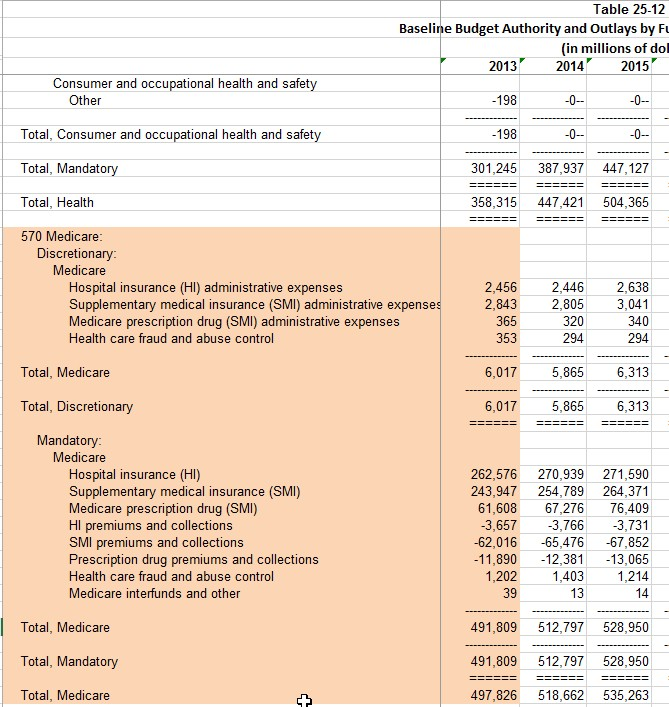

And here’s the summary of obligations in USASpending

```
##
##
## |cfda_program_num |cfda_program_title                       | fed_funding_amount|
## |:----------------|:----------------------------------------|------------------:|
## |93.773           |Medicare_Hospital Insurance              |             238.60|
## |93.774           |Medicare_Supplementary Medical Insurance |             219.65|
## |93.770           |Medicare_Prescription Drug Coverage      |              56.31|
```

```
## Grand Medicare sum from USASpending:  514.572416085
```

### Possible sources of information to use to allocate Medicare spending by state

Kaiser uses CMS State Health Expenditures (http://kff.org/medicare/state-indicator/medicare-spending-by-residence/)

[figure not shown]

But that is only available through 2009 so it would be a little dated

Here are some links to other potential sources but I haven’t had much chance to explore them:

http://www.kaiserhealthnews.org/stories/2013/november/30/post-acute-care-table-by-state.aspx

http://www.cms.gov/Research-Statistics-Data-and-Systems/Statistics-Trends-and-Reports/Medicare-Geographic-Variation/GV_PUF.html

http://www.cms.gov/Medicare/Health-Plans/MedicareAdvtgSpecRateStats/FFS-Data.html

The above appears to have Medicare FFS data. Also need MA Medicare advantage.

ftp://ftp.cdc.gov/pub/Health_Statistics/NCHS/Publications/Health_US/hus13tables/table133.xls

http://www.dartmouthatlas.org/

http://www.cms.gov/Research-Statistics-Data-and-Systems/Statistics-Trends-and-Reports/MCRAdvPartDEnrolData/index.html?redirect=/MCRAdvPartDEnrolData/MCESR/List.asp